# Прохождение внешнего курса. Часть 1

Презентация

Гайдук Софья Сергеевна

1032253645@rudn.ru

Российский университет дружбы народов

2026-05-10

## Title

# Информация

## Докладчик

- Гайдук Софья Сергеевна
- студент
- Российский университет дружбы народов им. П. Лумумбы
- 1032253645@rudn.ru
- https://github.com/SofiaGayduk/study_2025-2026_os-intro

# Цель работы

Изучить операционную систему Linux. Прохождение 1 этапа внешнего курса.

# Выполнение лабораторной работы

## Курс называется “Введение в Linux”, это написано в левом верхнем углу (рис. 1).

[figure not shown]

Figure 1: image1

## Из “Критерии прохождения курса” я выбрала все подходящие ответы (рис. 2).

[figure not shown]

Figure 2: image2

## Изначально пользовалась операционной системой Windows (рис. 3).

[figure not shown]

Figure 3: image3

## Это программа для работы одной операционной системы на другой. Мы установили VirtualBox (рис. 4).

[figure not shown]

Figure 4: image4

## Да, получилось (рис. 5).

[figure not shown]

Figure 5: image5

Создаем документ в LibreOffice Writer, записываем строку “Hello, Linux!” шрифтом FreeMono и сохраняем файл в формате XML. Прикрепляем файл к заданию (рис. 6).

[figure not shown]

Figure 6: image6

## Пакеты Linux(Ubuntu) имеют расширение deb (рис. 7).

[figure not shown]

Figure 7: image7

## Мы установили плеер VLC и, открыв его, увидели и записали первую фамилию (рис. 8).

[figure not shown]

Figure 8: image8

Update Manager используется для обновления установленного программного обеспечивания в Linux. Он устанавливает обновления безопасности и улучшает функциональность программы (рис. 9).

[figure not shown]

Figure 9: image9

## Терминал и консоль. Остальное не относится к “командной строке” (рис. 10).

[figure not shown]

Figure 10: image10

## Команда pwd (рис. 11).

[figure not shown]

Figure 11: image11

ls -A –human-readable -l здесь нет пути /some/directory, поэтому команда применится к текущей директории. Без указания пути это другая команда. ls AhI /some/directory здесь A – есть, -h – есть, -I – игнорировать файлы/паттерны. отсутствует -l и без него вывода в длинном формате не будет (рис. 12).

[figure not shown]

Figure 12: image12

Абсолютный путь — всегда корректно покажет нужную директорию, независимо от текущего расположения - подходит. Тильда ~ в bash заменяется на домашнюю директорию пользователя — /home/bi. Получается /home/bi/Downloads - подходит. ls Downloads покажет /home/bi/Documents/Downloads - не подходит. ./Downloads — то же самое, что Downloads (относительно текущей папки) - не подходит (рис. 13).

[figure not shown]

Figure 13: image13

## rm -r это команда удаления директорий и рекуррентное удаление файлов в ней (рис. 14).

[figure not shown]

Figure 14: image14

## Проверкой выясниллось, никто не закроется (рис. 15).

[figure not shown]

Figure 15: image15

## Ctrl+Z, bg это запуск в фоновом режиме программы (рис. 16).

[figure not shown]

Figure 16: image16

## После запуска файла мы видим вывод, показанный на скриншоте 18 (рис. 17, рис. 18).

[figure not shown]

Figure 17: image17

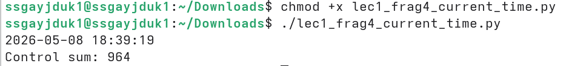

Figure 18: image18

## По умолчанию поток ошибок из программы в терминале выводится на экран (рис. 19).

[figure not shown]

Figure 19: image19

program 2> file.txt - направить стандартный поток ошибок в файл, если его нет, файл будет создан, есди есть - будет перезаписан сверху. program 2>> file.txt - направить стандартный поток ошибок в файл, если его нет, файл будет создан, есди есть - информация будет записана в конец (рис. 20).

[figure not shown]

Figure 20: image20

## Сообщения об ошибках выводятся на экран (рис. 21).

[figure not shown]

Figure 21: image21

В данной ситуации, файл скачивается и размещается с названием example.jpg в папке /home/alex/Pictures. После этот файл конвертируется в 1.jpg и добавляется в текущей директории, где мы находимся, так как указано только название файла и путь не прописан (рис. 22).

[figure not shown]

Figure 22: image22

## -q или -quiet (рис. 23).

[figure not shown]

Figure 23: image23

[figure not shown]

Figure 24: image24

## gzip удаляет архив после распаковки. zip при распаковке архив не удаляет (рис. 25).

[figure not shown]

Figure 25: image25

## Создать архив из директории с файлами могут zip и tar (рис. 26).

[figure not shown]

Figure 26: image26

## c - архиватор, j - указатель на тип архиватора bzip, f - создание архива в файловой системе (рис. 27).

[figure not shown]

Figure 27: image27

## Формат файла jpeg, а не jpg. Название файла Alexey, а не alexey. ? - один символ (рис. 28).

[figure not shown]

Figure 28: image28

## Все строки, в которых указано world. В остальных строках не найдет слова word и World (другое слово и регистр) (рис. 29).

[figure not shown]

Figure 29: image29

Скачаем архив, с помощью команды grep -r “love” Shakespeare/ > love.txt сгенерируем файл, в котором будут все строчки из этих произведений, содержащие “love”, и загрузим к заданию (рис. 30, рис. 31).

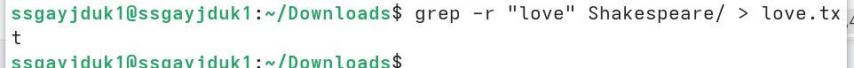

Figure 30: image30

[figure not shown]

Figure 31: image31

# Выводы

Изучили операционную систему Linux. Прошли 1 этап внешнего курса.

# Список литературы

1.Kulyabov. Прохождение внешнего курса. Часть 1. RUDN